# Data science session 3

Author

Ina

Published

January 24, 2024

```r
library(tidyverse)
library(palmerpenguins)
library(gapminder)
```

**Note**

This document includes both the week 3 live coding (as already uploaded in week 3) and the week 4 live coding additions, as a catch up for the topics that we didn’t manage to cover in week 3.

## Discussion of week 2 exercises

### Select

Select allows us to select particular columns. Use a minus sign to deselect columns.

```r
penguins |>
  select(species,sex,island)
```

```
# A tibble: 344 × 3
   species sex    island
   <fct>   <fct>  <fct>
 1 Adelie  male   Torgersen
 2 Adelie  female Torgersen
 3 Adelie  female Torgersen
 4 Adelie  <NA>   Torgersen
 5 Adelie  female Torgersen
 6 Adelie  male   Torgersen
 7 Adelie  female Torgersen
 8 Adelie  male   Torgersen
 9 Adelie  <NA>   Torgersen
10 Adelie  <NA>   Torgersen
# ℹ 334 more rows
```

```r
penguins |>
  select(-year)
```

```
# A tibble: 344 × 7
   species island    bill_length_mm bill_depth_mm flipper_length_mm body_mass_g
   <fct>   <fct>              <dbl>         <dbl>             <int>       <int>
 1 Adelie  Torgersen           39.1          18.7               181        3750
 2 Adelie  Torgersen           39.5          17.4               186        3800
 3 Adelie  Torgersen           40.3          18                 195        3250
 4 Adelie  Torgersen           NA            NA                  NA          NA
 5 Adelie  Torgersen           36.7          19.3               193        3450
 6 Adelie  Torgersen           39.3          20.6               190        3650
 7 Adelie  Torgersen           38.9          17.8               181        3625
 8 Adelie  Torgersen           39.2          19.6               195        4675
 9 Adelie  Torgersen           34.1          18.1               193        3475
10 Adelie  Torgersen           42            20.2               190        4250
# ℹ 334 more rows
# ℹ 1 more variable: sex <fct>
```

### Mutate

Mutate creates new columns, most typically based on existing ones.

```r
penguins |>
  mutate(body_mass_kg = body_mass_g/1000)
```

```
# A tibble: 344 × 9
   species island    bill_length_mm bill_depth_mm flipper_length_mm body_mass_g
   <fct>   <fct>              <dbl>         <dbl>             <int>       <int>
 1 Adelie  Torgersen           39.1          18.7               181        3750
 2 Adelie  Torgersen           39.5          17.4               186        3800
 3 Adelie  Torgersen           40.3          18                 195        3250
 4 Adelie  Torgersen           NA            NA                  NA          NA
 5 Adelie  Torgersen           36.7          19.3               193        3450
 6 Adelie  Torgersen           39.3          20.6               190        3650
 7 Adelie  Torgersen           38.9          17.8               181        3625
 8 Adelie  Torgersen           39.2          19.6               195        4675
 9 Adelie  Torgersen           34.1          18.1               193        3475
10 Adelie  Torgersen           42            20.2               190        4250
# ℹ 334 more rows
# ℹ 3 more variables: sex <fct>, year <int>, body_mass_kg <dbl>
```

### Size aesthetic

The size aesthetic maps a variable onto different sizes.

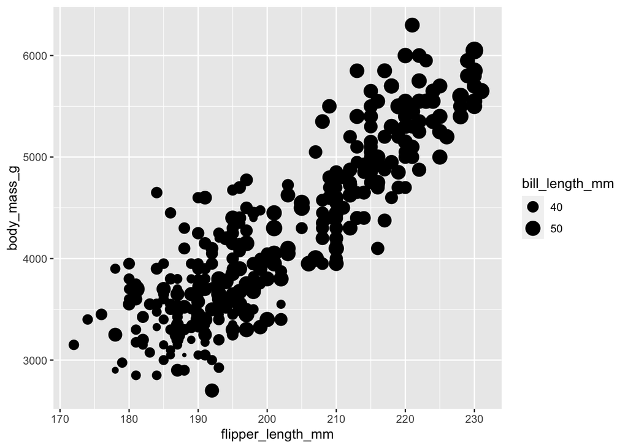

```r
penguins |>
  ggplot(aes(x = flipper_length_mm, y = body_mass_g,
             size = bill_length_mm)) +
  geom_point()
```

Use of size not as an aesthetic but to change the size of all points.

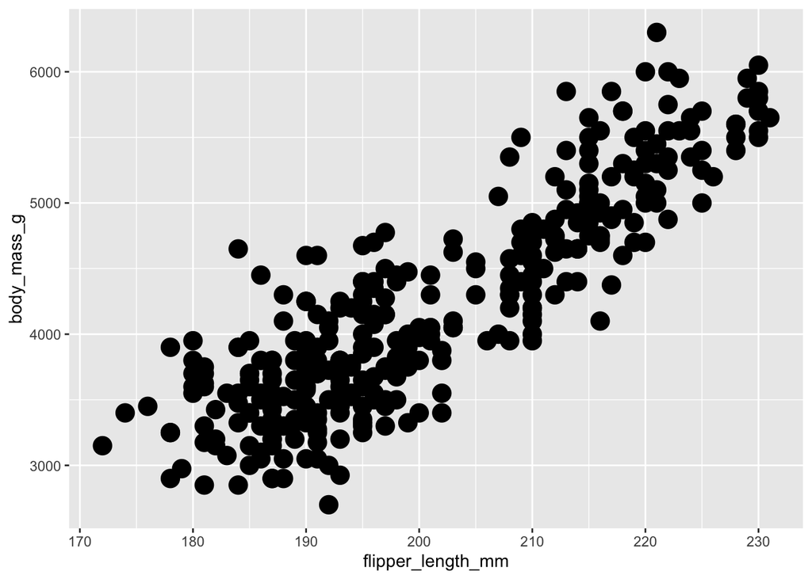

```r
penguins |>
  ggplot(aes(x = flipper_length_mm, y = body_mass_g)) +
  geom_point(size = 5)
```

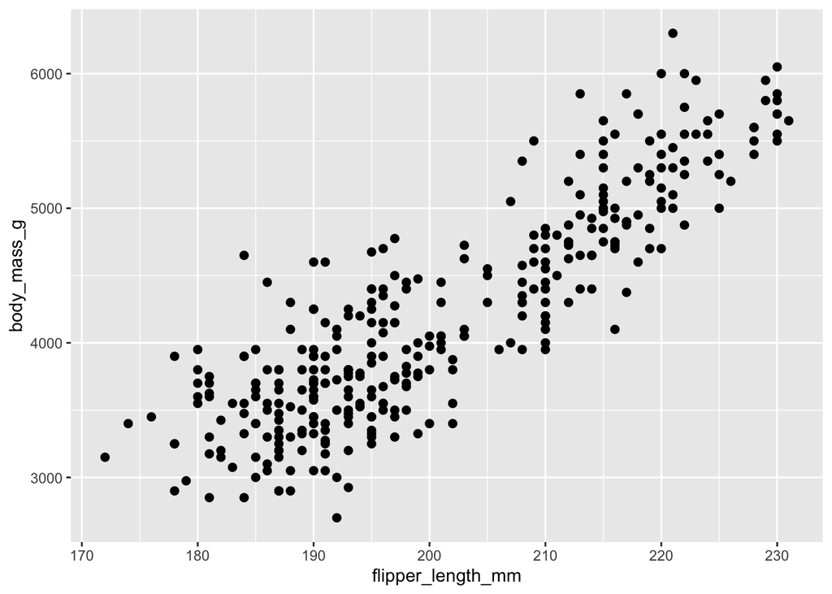

```r
penguins |>
  ggplot(aes(x = flipper_length_mm, y = body_mass_g)) +
  geom_point(size = 2)
```

Similar use of colour not as an aesthetic but to set a uniform colour:

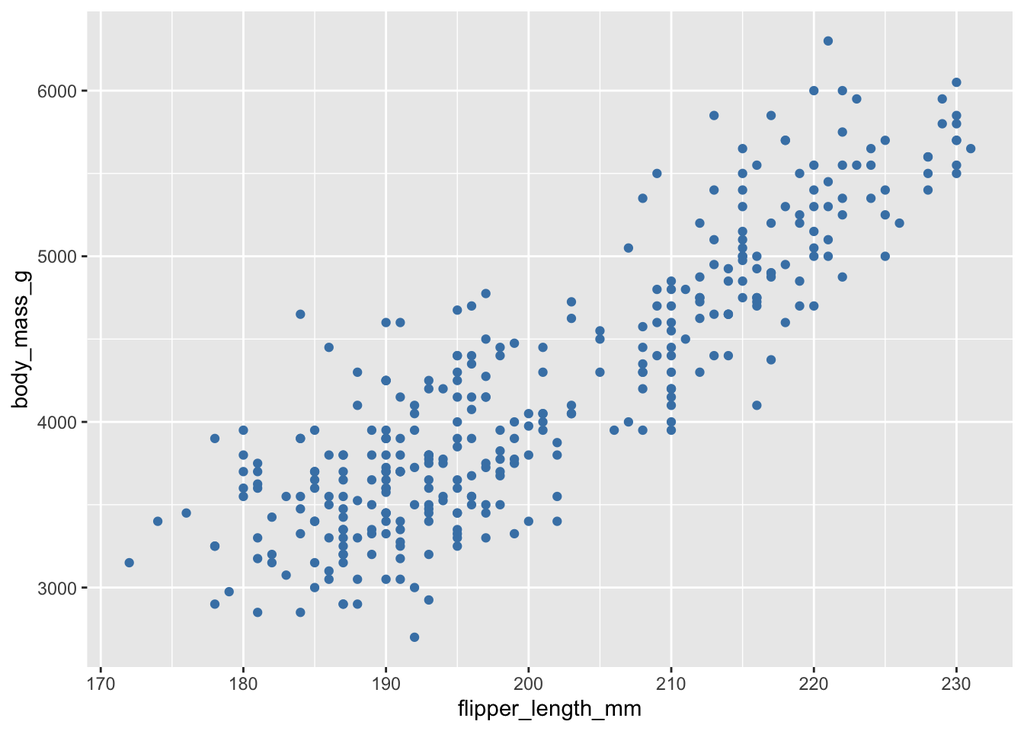

```r
penguins |>
  ggplot(aes(x = flipper_length_mm, y = body_mass_g)) +
  geom_point(colour = "steelblue")
```

Aesthetics can also be set just for individual geoms, as below. In this case, they will apply only to the geom in question, not to the entire plot (as when they are specified directly as an argument of `ggplot()`). We will return to this when we look at combining different geoms later in the course.

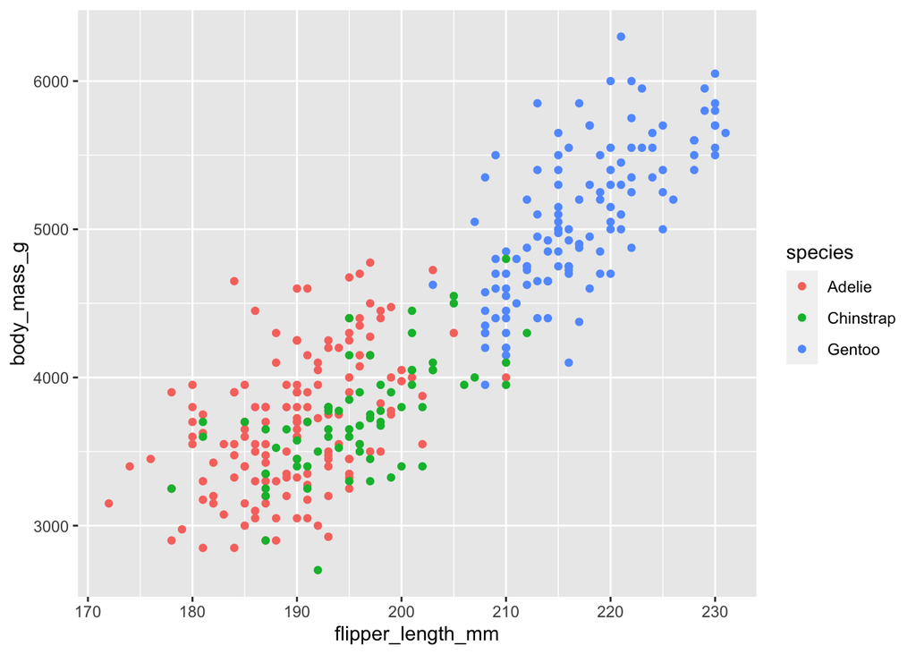

```r
penguins |>
  ggplot(aes(x = flipper_length_mm, y = body_mass_g)) +
  geom_point(aes(colour = species))
```

## R Basics

Create new objects with the assignment operator `<-`

```r
a <-  1 + 2
b <-  3 + 4
c <- "a text object"
```

What you can do with an object depends on its type, e.g. basic arithmetic with numeric objects only

```r
a + b
```

```
[1] 10
```

```r
# can't add b and c because c is a string
# b + c
```

To see the result of a computation that creates a new object, either type the name of the object to inspect it or enclose the operation in parentheses.

```r
(d <- a - b)
```

```
[1] -4
```

Example of a more complex object name

```r
this_is_a_really_long_name <- 2.5

this_is_too <-  3.5
```

Example of a function: `seq()`

```r
seq(1,10)
```

```
 [1]  1  2  3  4  5  6  7  8  9 10
```

```r
seq(1,100, by = 10)
```

```
 [1]  1 11 21 31 41 51 61 71 81 91
```

Be careful with brackets and quotation marks

```r
# x <- "hello world

# seq(1,10
```

## A little more on data manipulation

Create new objects from the penguins data

```r
adelies <- penguins |>
  filter(species == "Adelie")

adelies
```

```
# A tibble: 152 × 8
   species island    bill_length_mm bill_depth_mm flipper_length_mm body_mass_g
   <fct>   <fct>              <dbl>         <dbl>             <int>       <int>
 1 Adelie  Torgersen           39.1          18.7               181        3750
 2 Adelie  Torgersen           39.5          17.4               186        3800
 3 Adelie  Torgersen           40.3          18                 195        3250
 4 Adelie  Torgersen           NA            NA                  NA          NA
 5 Adelie  Torgersen           36.7          19.3               193        3450
 6 Adelie  Torgersen           39.3          20.6               190        3650
 7 Adelie  Torgersen           38.9          17.8               181        3625
 8 Adelie  Torgersen           39.2          19.6               195        4675
 9 Adelie  Torgersen           34.1          18.1               193        3475
10 Adelie  Torgersen           42            20.2               190        4250
# ℹ 142 more rows
# ℹ 2 more variables: sex <fct>, year <int>
```

### Additional ways to summarise

```r
penguins |>
  summarise(median_body_mass = median(body_mass_g, na.rm=TRUE))
```

```
# A tibble: 1 × 1
  median_body_mass
             <dbl>
1             4050
```

Other summary functions: `median()`, `min()`, `max()`

To look at groups use `group_by()`

```r
penguins |>
  group_by(species) |>
  summarise(median_body_mass = median(body_mass_g, na.rm = TRUE))
```

```
# A tibble: 3 × 2
  species   median_body_mass
  <fct>                <dbl>
1 Adelie                3700
2 Chinstrap             3700
3 Gentoo                5000
```

To look at the number of observations in a group use `count()`

```r
penguins |>
  count(species)
```

```
# A tibble: 3 × 2
  species       n
  <fct>     <int>
1 Adelie      152
2 Chinstrap    68
3 Gentoo      124
```

```r
penguins |>
  count(species,island)
```

```
# A tibble: 5 × 3
  species   island        n
  <fct>     <fct>     <int>
1 Adelie    Biscoe       44
2 Adelie    Dream        56
3 Adelie    Torgersen    52
4 Chinstrap Dream        68
5 Gentoo    Biscoe      124
```

### Additional ways to inspect data

The easiest way to inspect a data set is to type its name

```r
penguins
```

```
# A tibble: 344 × 8
   species island    bill_length_mm bill_depth_mm flipper_length_mm body_mass_g
   <fct>   <fct>              <dbl>         <dbl>             <int>       <int>
 1 Adelie  Torgersen           39.1          18.7               181        3750
 2 Adelie  Torgersen           39.5          17.4               186        3800
 3 Adelie  Torgersen           40.3          18                 195        3250
 4 Adelie  Torgersen           NA            NA                  NA          NA
 5 Adelie  Torgersen           36.7          19.3               193        3450
 6 Adelie  Torgersen           39.3          20.6               190        3650
 7 Adelie  Torgersen           38.9          17.8               181        3625
 8 Adelie  Torgersen           39.2          19.6               195        4675
 9 Adelie  Torgersen           34.1          18.1               193        3475
10 Adelie  Torgersen           42            20.2               190        4250
# ℹ 334 more rows
# ℹ 2 more variables: sex <fct>, year <int>
```

The functions `head()` and `tail()` display the first few and last few rows, respectively.

```r
head(penguins)
```

```
# A tibble: 6 × 8
  species island    bill_length_mm bill_depth_mm flipper_length_mm body_mass_g
  <fct>   <fct>              <dbl>         <dbl>             <int>       <int>
1 Adelie  Torgersen           39.1          18.7               181        3750
2 Adelie  Torgersen           39.5          17.4               186        3800
3 Adelie  Torgersen           40.3          18                 195        3250
4 Adelie  Torgersen           NA            NA                  NA          NA
5 Adelie  Torgersen           36.7          19.3               193        3450
6 Adelie  Torgersen           39.3          20.6               190        3650
# ℹ 2 more variables: sex <fct>, year <int>
```

```r
head(penguins, n=15)
```

```
# A tibble: 15 × 8
   species island    bill_length_mm bill_depth_mm flipper_length_mm body_mass_g
   <fct>   <fct>              <dbl>         <dbl>             <int>       <int>
 1 Adelie  Torgersen           39.1          18.7               181        3750
 2 Adelie  Torgersen           39.5          17.4               186        3800
 3 Adelie  Torgersen           40.3          18                 195        3250
 4 Adelie  Torgersen           NA            NA                  NA          NA
 5 Adelie  Torgersen           36.7          19.3               193        3450
 6 Adelie  Torgersen           39.3          20.6               190        3650
 7 Adelie  Torgersen           38.9          17.8               181        3625
 8 Adelie  Torgersen           39.2          19.6               195        4675
 9 Adelie  Torgersen           34.1          18.1               193        3475
10 Adelie  Torgersen           42            20.2               190        4250
11 Adelie  Torgersen           37.8          17.1               186        3300
12 Adelie  Torgersen           37.8          17.3               180        3700
13 Adelie  Torgersen           41.1          17.6               182        3200
14 Adelie  Torgersen           38.6          21.2               191        3800
15 Adelie  Torgersen           34.6          21.1               198        4400
# ℹ 2 more variables: sex <fct>, year <int>
```

```r
tail(penguins)
```

```
# A tibble: 6 × 8
  species   island bill_length_mm bill_depth_mm flipper_length_mm body_mass_g
  <fct>     <fct>           <dbl>         <dbl>             <int>       <int>
1 Chinstrap Dream            45.7          17                 195        3650
2 Chinstrap Dream            55.8          19.8               207        4000
3 Chinstrap Dream            43.5          18.1               202        3400
4 Chinstrap Dream            49.6          18.2               193        3775
5 Chinstrap Dream            50.8          19                 210        4100
6 Chinstrap Dream            50.2          18.7               198        3775
# ℹ 2 more variables: sex <fct>, year <int>
```

`glimpse()` shows the columns in a horizontal layout

```r
glimpse(penguins)
```

```
Rows: 344
Columns: 8
$ species           <fct> Adelie, Adelie, Adelie, Adelie, Adelie, Adelie, Adel…
$ island            <fct> Torgersen, Torgersen, Torgersen, Torgersen, Torgerse…
$ bill_length_mm    <dbl> 39.1, 39.5, 40.3, NA, 36.7, 39.3, 38.9, 39.2, 34.1, …
$ bill_depth_mm     <dbl> 18.7, 17.4, 18.0, NA, 19.3, 20.6, 17.8, 19.6, 18.1, …
$ flipper_length_mm <int> 181, 186, 195, NA, 193, 190, 181, 195, 193, 190, 186…
$ body_mass_g       <int> 3750, 3800, 3250, NA, 3450, 3650, 3625, 4675, 3475, …
$ sex               <fct> male, female, female, NA, female, male, female, male…
$ year              <int> 2007, 2007, 2007, 2007, 2007, 2007, 2007, 2007, 2007…
```

## Plotting

### Scatterplots for two continuous variables

Scatterplot example, which also shows how to add title and axis labels. Adding a meaningful title and axis labels makes your plot more informative and readable.

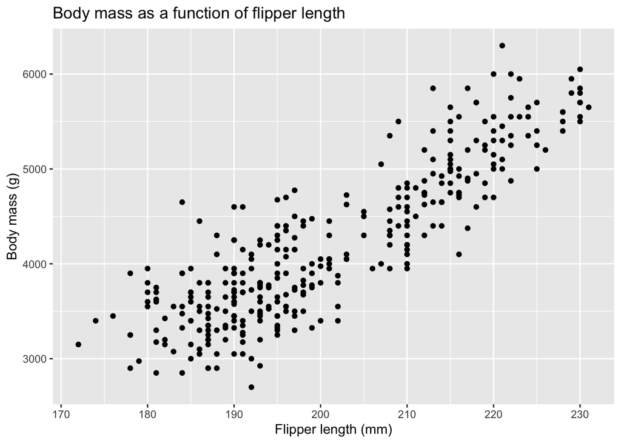

```r
penguins |>
  ggplot(aes(x = flipper_length_mm, y = body_mass_g)) +
  geom_point() +
  labs(
    title = "Body mass as a function of flipper length",
    x = "Flipper length (mm)",
    y = "Body mass (g)"
  )
```

### Plotting a categorical predictor of a continuous variable

What about species as a predictor of body mass?

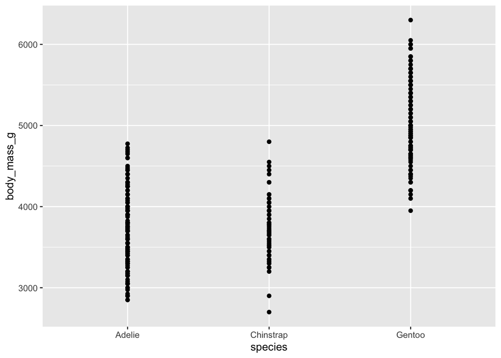

```r
penguins |>
  ggplot(aes(x = species, y = body_mass_g)) +
  geom_point()
```

`geom_jitter()` produces a better result:

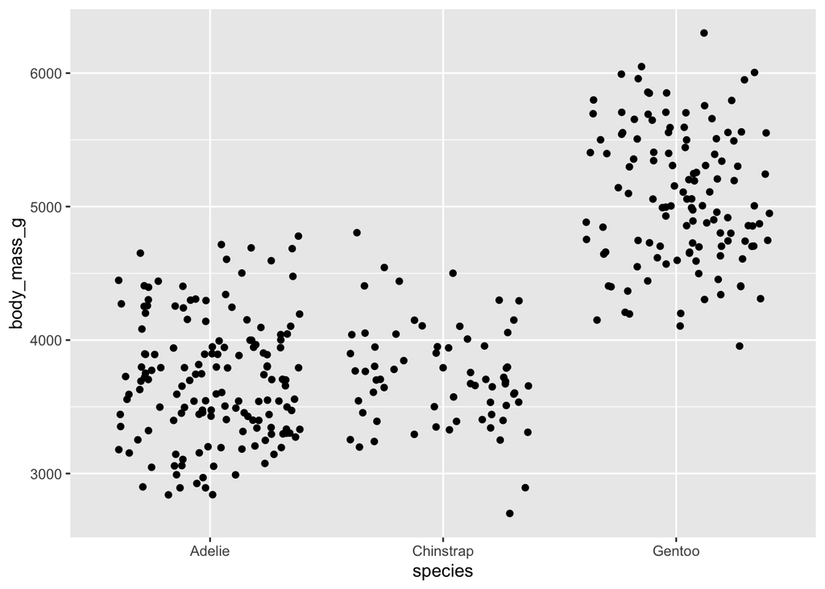

```r
penguins |>
  ggplot(aes(x = species, y = body_mass_g)) +
  geom_jitter()
```

### Bar / column graphs to plot quantities

Alternative approach: plot mean body mass by species using a bar / column graph with `geom_col()`:

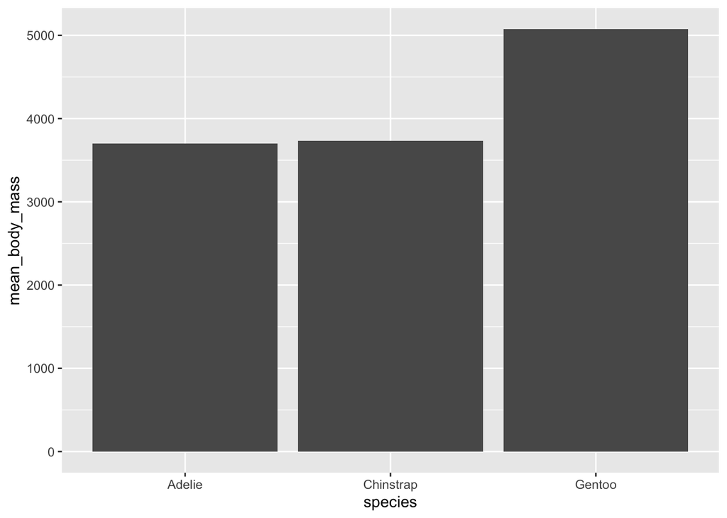

```r
penguins |>
  group_by(species) |>
  summarise(mean_body_mass = mean(body_mass_g, na.rm=TRUE)) |>
  ggplot(aes(x = species, y = mean_body_mass)) +
  geom_col()
```

It is crucial to summarise first in order to only have one value per species, otherwise the plot won’t show what you think:

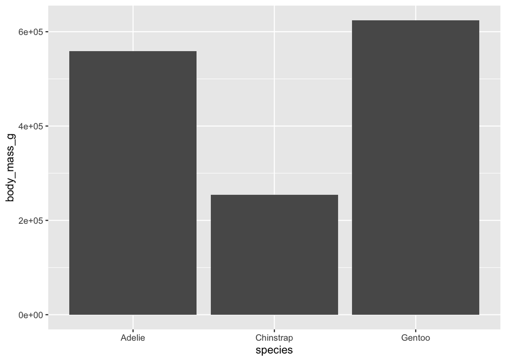

```r
penguins |>
  ggplot(aes(x = species, y = body_mass_g)) +
  geom_col()
```

Note that there is also a `geom_bar()`. Have a look at the documentation: what is the difference between `geom_col()` and `geom_bar()`?

### Line graphs to plot changes over time

Line graph to plot the number of sightings per year We first need to count the number of sightings

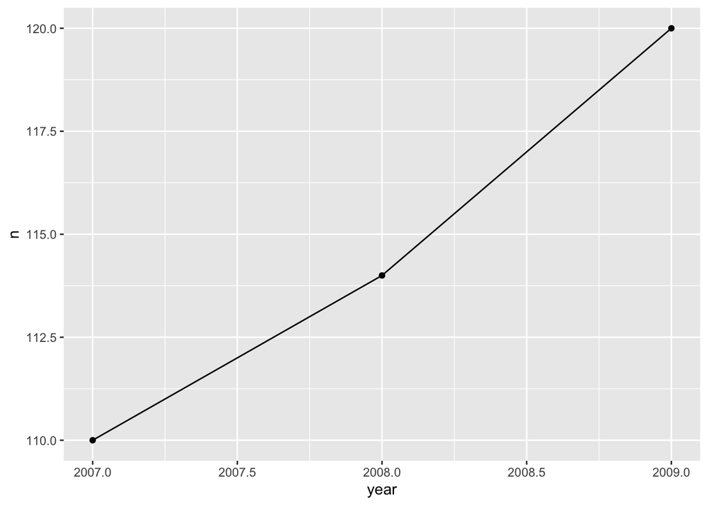

```r
penguins |>
  count(year) |>
  ggplot(aes(x = year, y = n)) +
  geom_line() +
  geom_point()
```

Adding groups, e.g. to look at the number of sightings per year for each species:

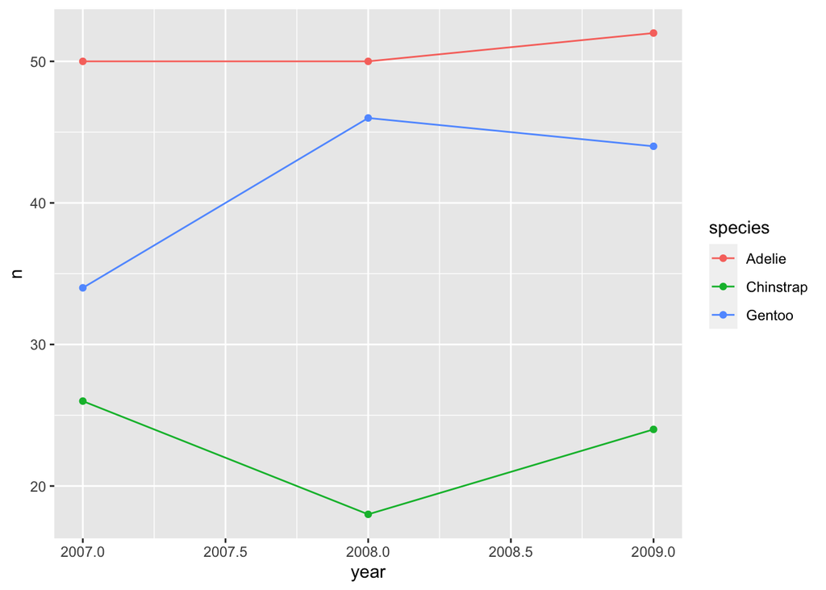

```r
penguins |>
  count(year, species) |>
  ggplot(aes(x = year, y = n, colour = species)) +
  geom_line() +
  geom_point()
```

Selecting aesthetics for one geom only:

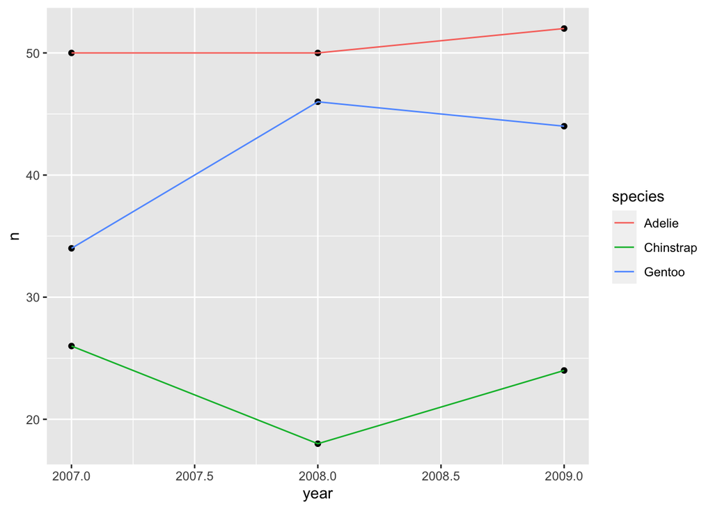

```r
penguins |>
  count(year, species) |>
  ggplot(aes(x = year, y = n)) +
    geom_point() +
    geom_line(aes(colour = species))
```

### Histograms to examine distributions

Use a histogram to look at a distribution (e.g. of bill depth).

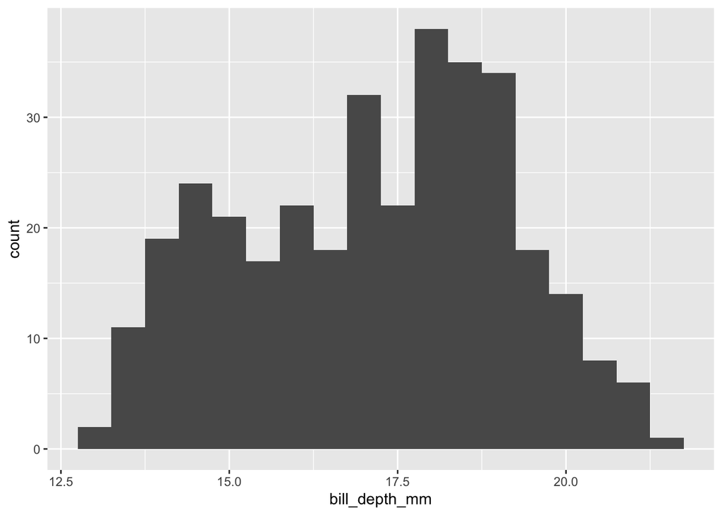

```r
penguins |>
  ggplot(aes(x = bill_depth_mm)) +
  geom_histogram(binwidth = 0.5)
```

Pair a histogram with facets to look at groups:

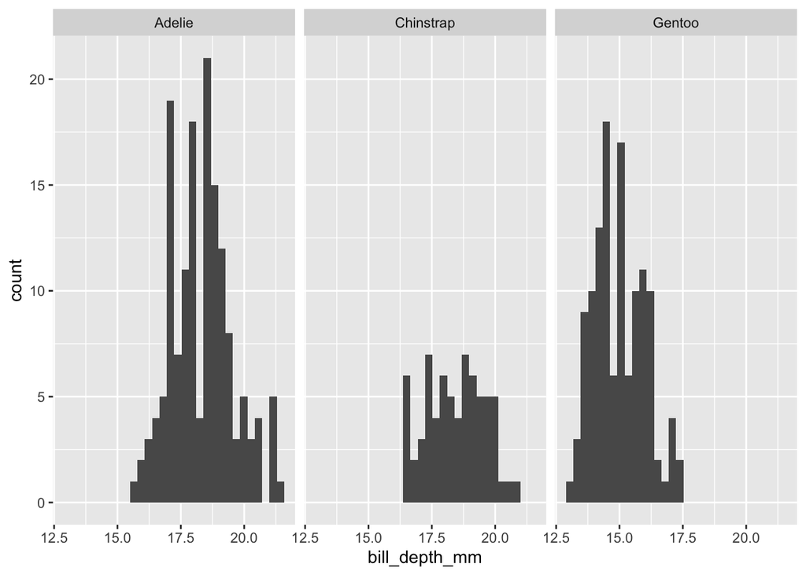

```r
penguins |>
  ggplot(aes(x = bill_depth_mm)) +
  geom_histogram(bindwidth = 0.5) +
  facet_wrap(~species)
```

### Boxplots to examine distributions

- Line = median
- Lower edge of box = 1st quartile
- Upper edge of box = 3rd quartile
- Whiskers extend to largest / smallest value, maximally 1.5 interquartile ranges from edge of box
- Data points beyond the whiskers are deemed outliers and plotted individually

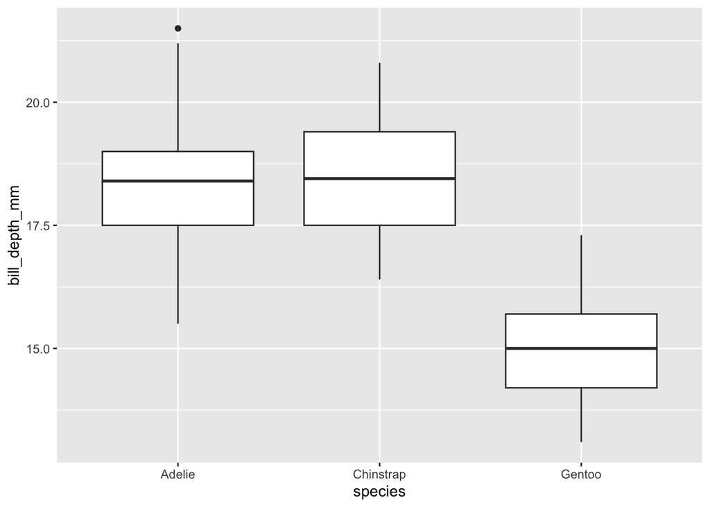

```r
penguins |>
  ggplot(aes(x = species, y = bill_depth_mm)) +
  geom_boxplot()
```

Add colour fill:

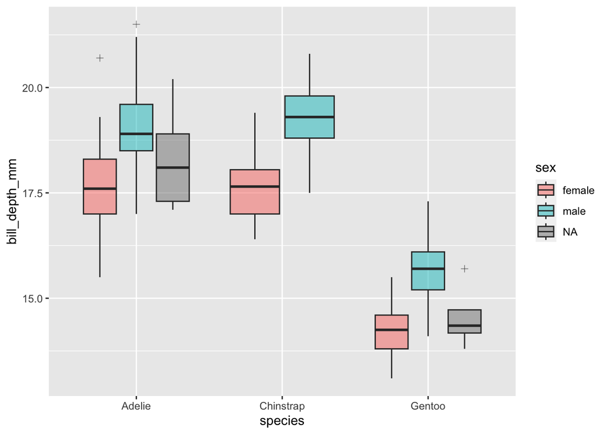

```r
penguins |>
  ggplot(aes(x = species, y = bill_depth_mm, fill = sex)) +
  geom_boxplot(outlier.shape = 3, alpha = 0.5)
```

## Gapminder data

```r
summary(gapminder)
```

```
        country        continent        year         lifeExp
 Afghanistan:  12   Africa  :624   Min.   :1952   Min.   :23.60
 Albania    :  12   Americas:300   1st Qu.:1966   1st Qu.:48.20
 Algeria    :  12   Asia    :396   Median :1980   Median :60.71
 Angola     :  12   Europe  :360   Mean   :1980   Mean   :59.47
 Argentina  :  12   Oceania : 24   3rd Qu.:1993   3rd Qu.:70.85
 Australia  :  12                  Max.   :2007   Max.   :82.60
 (Other)    :1632
      pop              gdpPercap
 Min.   :6.001e+04   Min.   :   241.2
 1st Qu.:2.794e+06   1st Qu.:  1202.1
 Median :7.024e+06   Median :  3531.8
 Mean   :2.960e+07   Mean   :  7215.3
 3rd Qu.:1.959e+07   3rd Qu.:  9325.5
 Max.   :1.319e+09   Max.   :113523.1
```

- How has life expectancy in Germany changed over time?

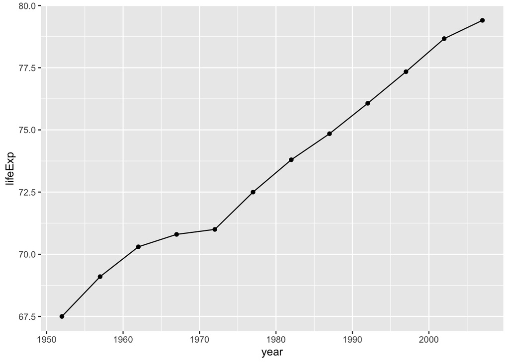

```r
gapminder |>
  filter(country == "Germany") |>
  ggplot(aes(x = year, y = lifeExp)) +
  geom_line() +
  geom_point()
```

- What was the relationship between life expectancy and how wealthy a country is (gdpPercap) in 1952? In 2007?

Start by looking at 1952:

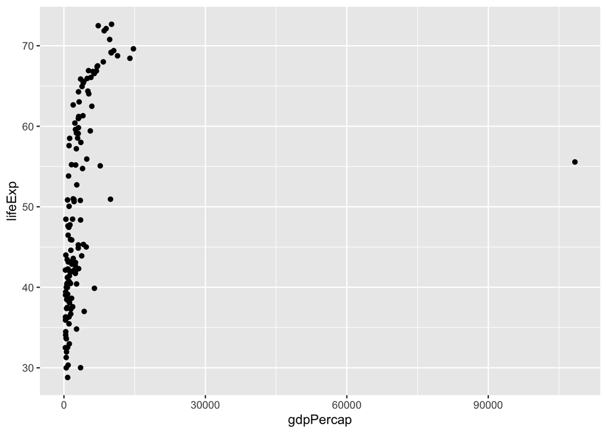

```r
gapminder |>
  filter(year == 1952) |>
  ggplot(aes(x = gdpPercap, y = lifeExp)) +
  geom_point()
```

Identify the outlier:

```r
gapminder |>
  filter(year == 1952, gdpPercap > 90000)
```

```
# A tibble: 1 × 6
  country continent  year lifeExp    pop gdpPercap
  <fct>   <fct>     <int>   <dbl>  <int>     <dbl>
1 Kuwait  Asia       1952    55.6 160000   108382.
```

Remove the outlier:

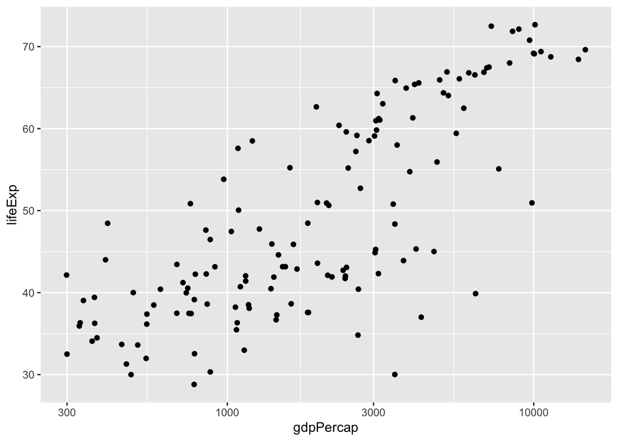

```r
gapminder |>
  filter(year == 1952, gdpPercap < 90000) |>
  ggplot(aes(x = gdpPercap, y = lifeExp)) +
  geom_point() +
  scale_x_log10()
```

Note that even after removing the outlier, there were still many datapoints “squashed together” close to 0, suggesting that there is a disparity of scale in regard to `gdpPercap` (i.e. the values of this variable for different countries are on different orders of magnitude). We have addressed this using a log scale (via the addition of `scale_x_log10()`).

**We did not look at 2007 in the workshop on account of time constraints. However, the approach to do this would be parallel to the above.**

- How did the mean life expectancy per continent change over time?

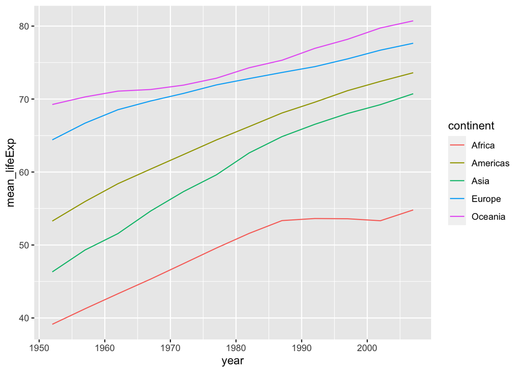

```r
gapminder |>
  group_by(continent, year) |>
  summarise(mean_lifeExp = mean(lifeExp, na.rm = TRUE)) |>
  ggplot(aes(x = year, y = mean_lifeExp, colour = continent)) +
  geom_line()
```

**The below question was not examined in the workshop due to time constraints.**

- Which continent had the highest variability in population across countries? Pick two years of your choice to examine.